# Projektbericht – Statistische Kennwerte & Visualisierungen

Ermin Zoronjic

Salih Hasicic

12. Dezember 2025

# 1 Einleitung

In diesem Projektbericht dokumentieren wir unser Vorgehen zur Berechnung statistischer Kennwerte (Mittelwert, Median, Modus, Varianz, Standardabweichung) für ausgewählte Variablen und halten die Ergebnisse in einem reproduzierbaren R Markdown Dokument fest. Zudem visualisieren wir die Verteilungen der Merkmale grafisch (Histogramme, Boxplots, Balkendiagramme).

# 2 Daten einlesen und vorbereiten

Wichtig: Beim *Knit* wird R neu gestartet. Deshalb müssen Pakete und Datensatz *im Dokument* geladen werden.

```r
# Pakete laden
# Falls noch nicht installiert:
# install.packages("readxl")
# install.packages("dplyr")
# install.packages("knitr")

library(readxl)
library(dplyr)
library(knitr)

# Daten einlesen
df <- read_excel(
  "GUESSS_SWITZERLAND_Final.xlsx",
  sheet = "GUESSS_SWITZERLAND_Final_2"
)

# '.' als Missing (NA) behandeln und in numerisch umwandeln
likert_cols <- c(
  "Q4.1.1_1","Q4.1.1_2","Q4.1.1_3",
  "Q4.1.1_4","Q4.1.1_5","Q4.1.1_6",
  "Q6.2_1"
)

df <- df %>%
  mutate(across(
    all_of(likert_cols),
    ~ as.numeric(na_if(as.character(.x), "."))
  ))
```

# 3 Statistische Kennwerte

## 3.1 Ausgewählte Variablen

Wir analysieren folgende Variablen:

- `EI_mean`: Skala aus den Intention-Items (`Q4.1.1_1` bis `Q4.1.1_6`)
- `Q6.2_1_family`: soziale Norm – Familie (`Q6.2_1`)
- `Q2.2_in_process`: im Gründungsprozess (0/1)
- `Q2.3_self_employed`: bereits selbständig (0/1)

## 3.2 Berechnung und Tabelle

Im folgenden Chunk wird der Code im Bericht ausgeblendet (`echo = FALSE`), die Resultate werden jedoch angezeigt.

| Variable | N | Mittelwert | Median | Modus | Varianz | SD |
| --- | --- | --- | --- | --- | --- | --- |
| EI_mean | 8853 | 2.767 | 2.333 | 1 | 2.851 | 1.689 |
| Q6.2_1_family | 9747 | 5.504 | 6.000 | 7 | 1.845 | 1.358 |
| Q2.2_in_process | 9784 | 0.081 | 0.000 | 0 | 0.074 | 0.273 |
| Q2.3_self_employed | 9784 | 0.024 | 0.000 | 0 | 0.023 | 0.153 |

# 4 Grafische Darstellung der Merkmalsausprägungen

In diesem Abschnitt visualisieren wir die Verteilungen der ausgewählten Variablen. Wir verwenden:

- ein Histogramm für `EI_mean`
- ein Boxplot für `EI_mean` nach Gründungsprozess (`Q2.2`)
- ein Histogramm für `Q6.2_1` (Norm Familie)
- Balkendiagramme für `Q2.2` und `Q2.3`

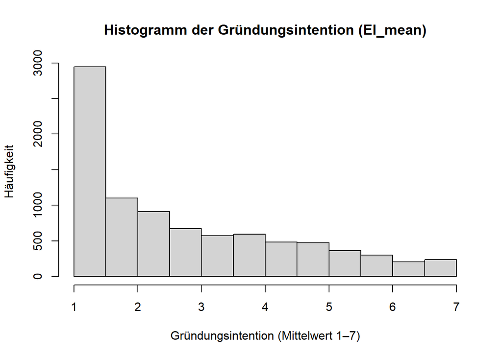

```r
# Faktoren für die 0/1-Variablen für schönere Achsenbeschriftung
df$Q2.2_factor <- factor(
  df$Q2.2,
  levels = c(0, 1),
  labels = c("nein", "ja")
)

df$Q2.3_factor <- factor(
  df$Q2.3,
  levels = c(0, 1),
  labels = c("nein", "ja")
)

# 1) Histogramm der Gründungsintention (EI_mean)
hist(
  df$EI_mean,
  main  = "Histogramm der Gründungsintention (EI_mean)",
  xlab  = "Gründungsintention (Mittelwert 1–7)",
  ylab  = "Häufigkeit",
  breaks = 20
)
```

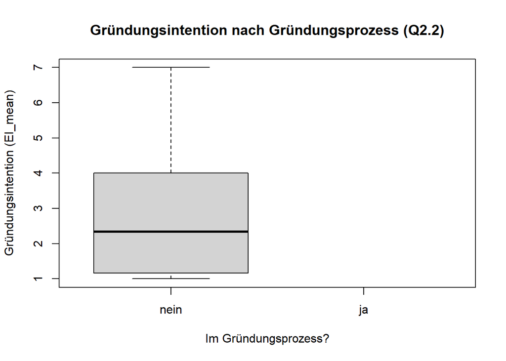

```r
# 2) Boxplot: EI_mean nach Gründungsprozess (Q2.2)
boxplot(
  EI_mean ~ Q2.2_factor,
  data  = df,
  main  = "Gründungsintention nach Gründungsprozess (Q2.2)",
  xlab  = "Im Gründungsprozess?",
  ylab  = "Gründungsintention (EI_mean)"
)
```

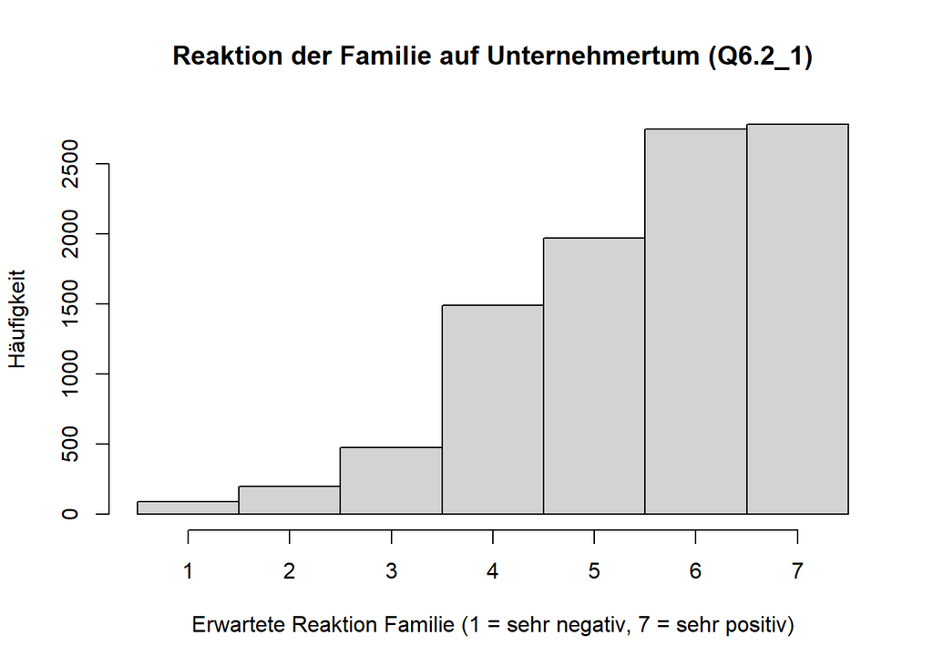

```r
# 3) Histogramm: Soziale Norm – Familie (Q6.2_1)
hist(
  df$Q6.2_1,
  main   = "Reaktion der Familie auf Unternehmertum (Q6.2_1)",
  xlab   = "Erwartete Reaktion Familie (1 = sehr negativ, 7 = sehr positiv)",
  ylab   = "Häufigkeit",
  breaks = seq(0.5, 7.5, by = 1)
)
```

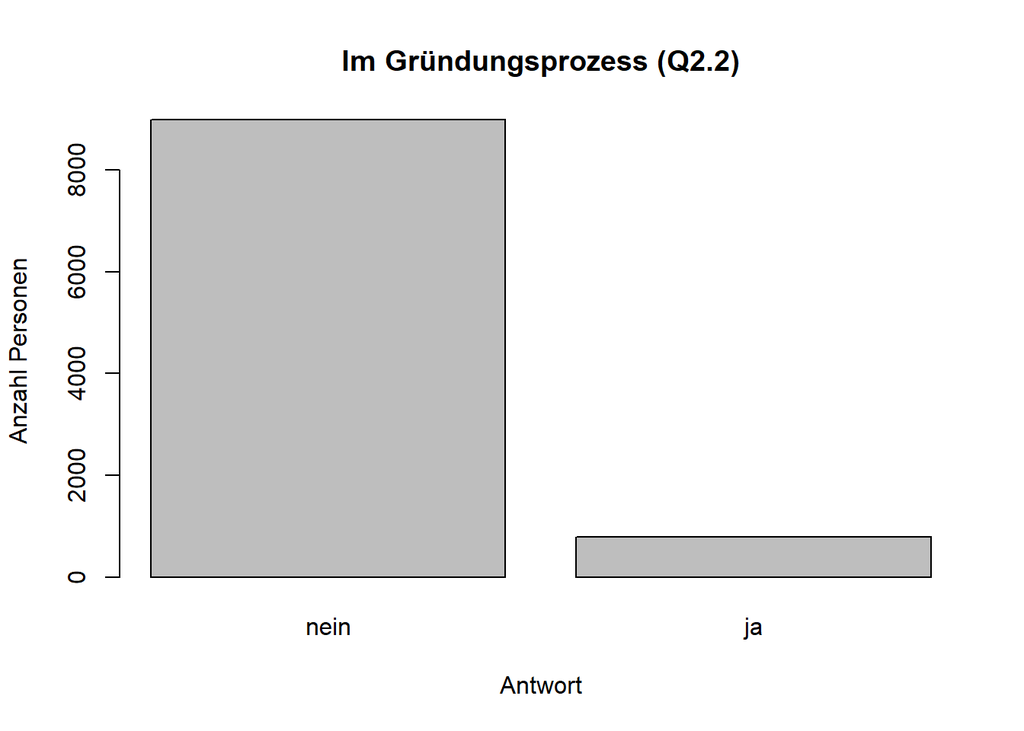

```r
# 4) Balkendiagramm: Im Gründungsprozess (Q2.2)
tab_q22 <- table(df$Q2.2_factor)

barplot(
  tab_q22,
  main = "Im Gründungsprozess (Q2.2)",
  xlab = "Antwort",
  ylab = "Anzahl Personen"
)
```

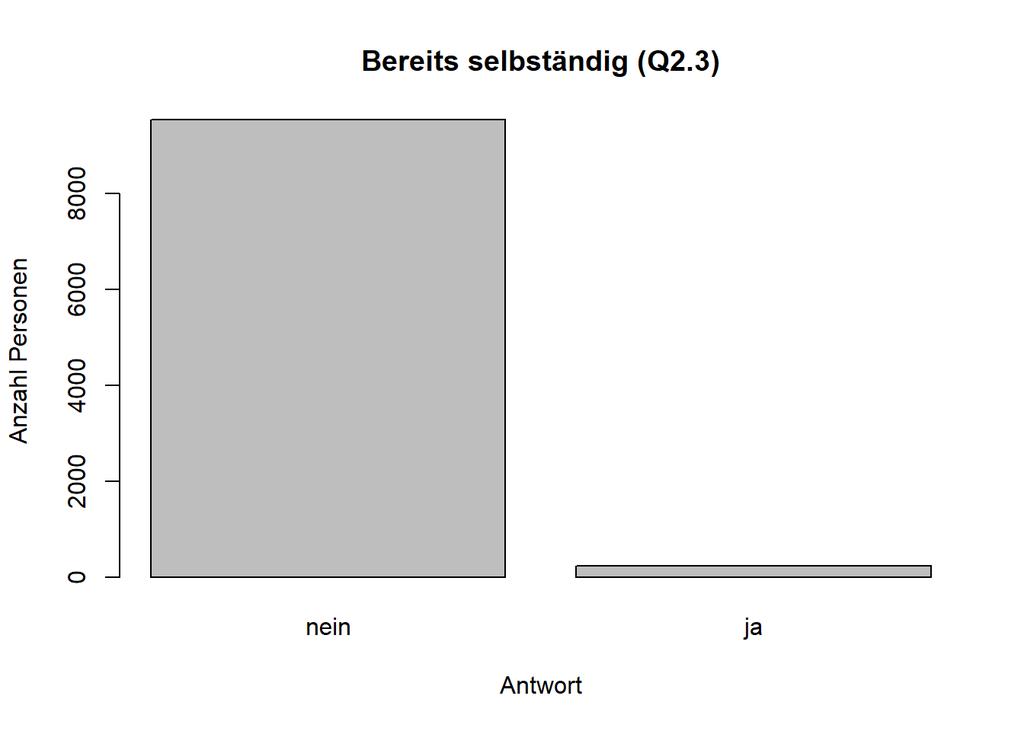

```r
# 5) Balkendiagramm: Bereits selbständig (Q2.3)
tab_q23 <- table(df$Q2.3_factor)

barplot(
  tab_q23,
  main = "Bereits selbständig (Q2.3)",
  xlab = "Antwort",
  ylab = "Anzahl Personen"
)
```

# 5 Interpretation der Ergebnisse (Stichworte)

- **Gründungsintention (`EI_mean`)**  
  Die Verteilung zeigt, ob sich die meisten Studierenden eher im unteren oder oberen Bereich der Skala befinden.  
  Ein niedriger Mittelwert und eine rechts-schiefe Verteilung würden auf insgesamt eher geringe Gründungsintention hinweisen.
- **Norm Familie (`Q6.2_1`)**  
  Das Histogramm gibt Aufschluss darüber, ob die meisten Familiengründungen positiv oder negativ bewerten.  
  Eine Häufung im Bereich 5–7 spricht für grosse Unterstützung.
- **Nominale Variablen (`Q2.2`, `Q2.3`)**  
  Die Balkendiagramme machen sichtbar, dass (vermutlich) nur ein kleiner Anteil im Gründungsprozess ist oder bereits selbständig ist.  
  Die starke Unbalance ist wichtig für die Interpretation späterer Modelle (z. B. logistische Regression).